# BT1101 Practice Exam

25 Nov 2021, 1:00 - 3:30 PM

## Instructions

- **Rename your R Markdown file `FE_[MatricNumber].rmd`**, and the output will automatically be `FE_[MatricNumber].html`.
- Select `output: html_document`.
- Include all code chunks, so include `echo=TRUE` in all chunks.
- Replace the placeholder text, “Type your answer here.”, with your own.
- Preinstall and include any `library('package_name')` statements before exam starts. Remember that there is no Internet connection during the exam.
- Code and type your answer in this Rmarkdown file during exam but **keep in mind that you need to copy and paste all your answer (r-chunk and text) into Essay Answer section for each question in Examplify.**
- Submit your both R Markdown file (.rmd) and HTML (.html) to the folder “Final Exam Submission” in Luminus after Examplify submission and Internet reconnection.
- This Rmarkdown file serves as a reference. **Only answers submitted in Examplify will be graded.** Zero point will be given for blank submission in Examplify even if you have submitted a complete Rmarkdown/HTML file.

## Preparation

```r
# predictive/prescriptive analytics
#library(tseries)
#library(forecast)
library(lpSolve)

# descriptive analytics
library(psych)
library(Rmisc)
library(rcompanion)
library(rpivotTable)
library(EnvStats)
library(car)
library(rstatix)

# general use
library(wooldridge)
library(dplyr)
library(tidyr)
library(knitr)
```

```r
# load the data set, make sure you already loaded `wooldridge` package
data('gpa2')
data <-gpa2
```

This data set is from a midsize research university. It has 4137 observations on 12 variables: - `sat`: combined SAT score (includes verbal, writing and maths score) - `tothrs`: total hours through fall semester - `colgpa`: GPA after fall semester - `athlete`: =1 if athlete - `verbmath`: verbal and math SAT score - `hsize`: size of high school graduation class, 100s - `hsrank`: rank in high school graduation class (where rank 1 is top in the class) - `hsperc`: high school percentile, from top (i.e. a value of “10” means “top 10 percent in high school”) - `female`: =1 if female - `white`: =1 if white - `black`: =1 if black - `hsizesq`: hsize^2

1.(a) This dataset comprises 4 demographic variables (`athlete`, `female`, `white`, `black`) on students. i) Create a table to display the frequency of students in the dataset for each category defined by the combination of all 4 variables. You can use a normal table or a pivot table. You may exclude combination(s) with no occurrence in the table. (1 mark) ii) Based on the table in (ai), what is the difference in number of black male athlete students to non-black male athlete students? (1 mark)

```r
data4 <- data %>% select(c("athlete","female","black"))
rpivotTable(data4, rows ="athlete", cols=c("female","black"),aggregatorName = "Count")
```

[interactive table not shown]

```r
#black male athlete = 33
#non black male athlete = 116
#difference = 83
```

2. There are a few variables that measure the performance of students, namely `sat`, `colgpa`, `verbmath`, `hsrank` and `hsperc`. You may treat these as continuous random variables.
1. The university is interested to know if there is any linear relationship between `colgpa` and high school performance (`sat`, `verbmath`, `hsrank` and `hsperc`). Check this visually as well as with the appropriate statistical measure(s). Interpret your results. (2 marks) ensure all graphs are clearly labeled with the appropriate titles and axes names.
2. Compute and interpret the 99% prediction interval for `colgpa`. (2 marks)

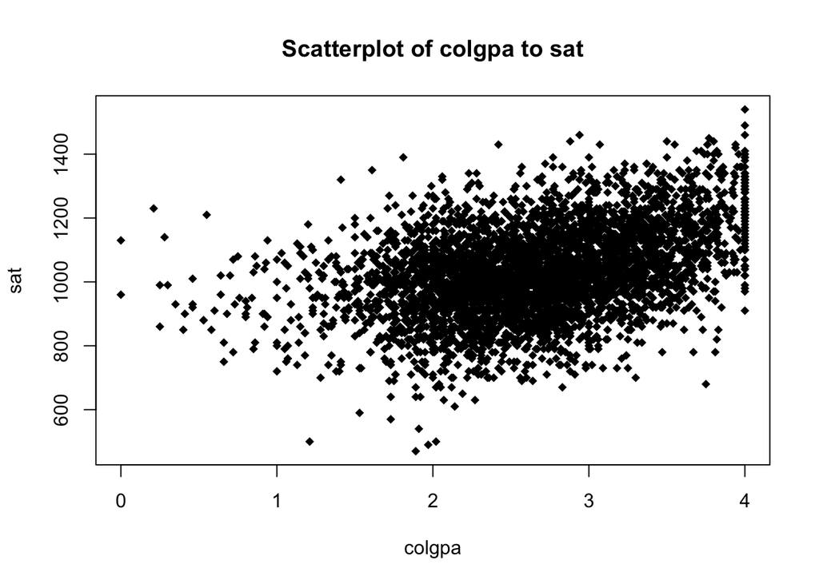

```r
#use scatterplot to determine visually
plot(data$colgpa , data$sat, main="Scatterplot of colgpa to sat", xlab="colgpa", ylab="sat", pch=18)
```

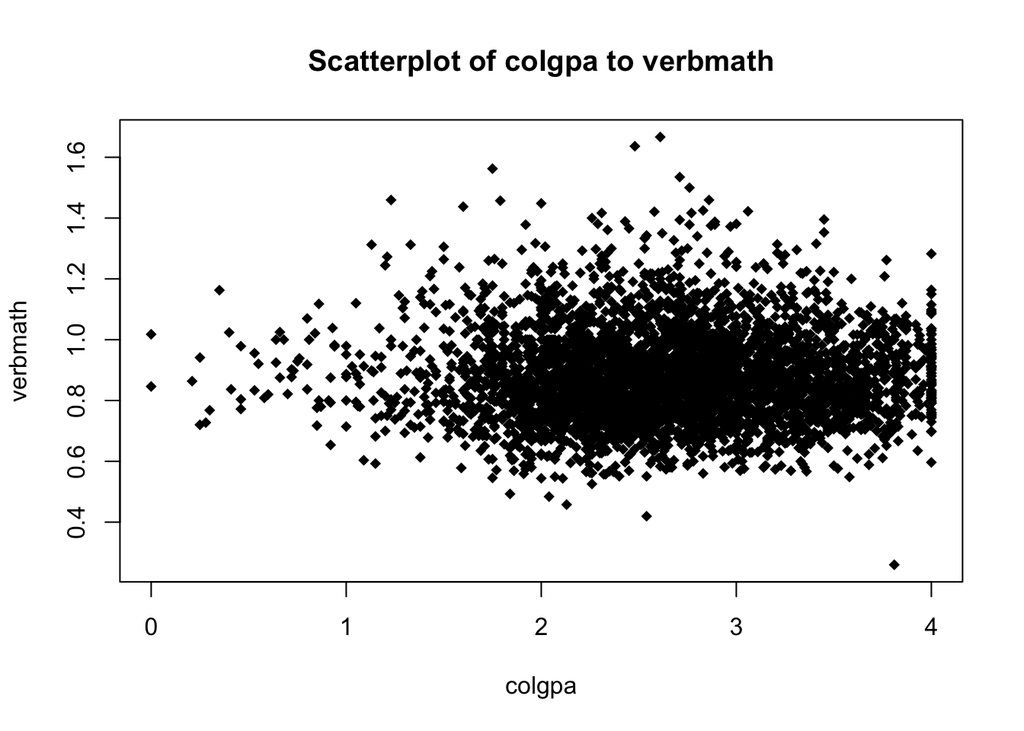

```r
plot(data$colgpa , data$verbmath, main="Scatterplot of colgpa to verbmath", xlab="colgpa", ylab="verbmath", pch=18)
```